# Inference by hand and in R

Student worksheet · Quantitative Methods in Geography

All examples are fictional. = Each student runs one simulation and contributes one statistic to the whiteboard before running many simulations. Work through each section in order in a fresh R session. The accompanying `.R` script contains the same workflows. Everyone needs a different assigned seat number. Record your number and run each block from its `set.seed(...)` line to reproduce your results at home. Do not run the entire worksheet before the class discussions.

## 1. Sampling variability

**In class:** first run the setup and replace `seat_number <- 1` with your assigned number. Run only the `my_sample` block. Inspect its five observations and calculate one sample mean. Add that mean to the whiteboard. Predict the class pattern before running 2,000 samples.

**Prediction:** what happens to the spread of sample means if the sample size increases from 5 to 20?

```r
# Foundations of inference — Quantitative Methods in Geography
# All data are fictional. Run from the top, in a clean R session.
# Install once if needed:
# install.packages(c("tidyverse", "infer"))
library(tidyverse)
library(infer)

# Your instructor assigns everyone a different seat number: 1, 2, 3, ...
# Replace 1 with YOUR assigned number. Record it to reproduce your work.
seat_number <- 1
student_seed <- 1000 + seat_number
# Re-running a block with the same seed repeats the same random results.
# More replicates in generate() produce multiple simulations in one run.

# 1. SAMPLING VARIABILITY: known toy city, independent draws
city <- tibble(minutes = seq(5, 30, by = 5))
mean(city$minutes) # known population mean = 17.5
```

```
[1] 17.5
```

### One sample first

Run this chunk and contribute one sample mean to the board.

```r
# FIRST: inspect one sample and contribute one mean to the whiteboard.
set.seed(student_seed)
my_sample <- city |>
  rep_sample_n(size = 5, reps = 1, replace = TRUE)
my_sample # five draws; a value may appear more than once
```

```
# A tibble: 5 × 2
# Groups:   replicate [1]
  replicate minutes
      <int>   <dbl>
1         1      15
2         1      15
3         1      30
4         1      30
5         1      20
```

```r
my_sample |>
  summarise(sample_mean = mean(minutes), .groups = "drop")
```

```
# A tibble: 1 × 2
  replicate sample_mean
      <int>       <dbl>
1         1          22
```

**Pause:** discuss the class dotplot before continuing.

### Many samples

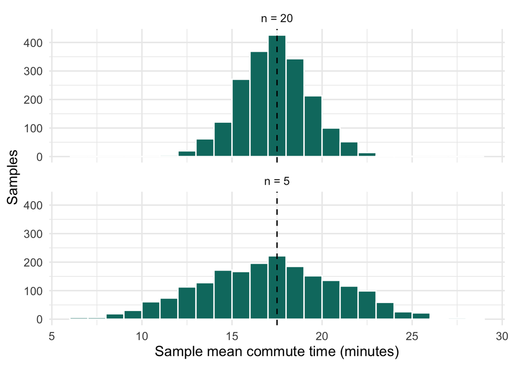

```r
# THEN: produce many samples to see the pattern.
set.seed(student_seed + 1)
sampling_5 <- city |>
  rep_sample_n(size = 5, reps = 2000, replace = TRUE) |>
  summarise(stat = mean(minutes), .groups = "drop")
sampling_20 <- city |>
  rep_sample_n(size = 20, reps = 2000, replace = TRUE) |>
  summarise(stat = mean(minutes), .groups = "drop")

sampling_comparison <- bind_rows(
  mutate(sampling_5, sample_size = "n = 5"),
  mutate(sampling_20, sample_size = "n = 20")
)
ggplot(sampling_comparison, aes(stat)) +
  geom_histogram(binwidth = 1, boundary = 0, fill = "#06796f", color = "white") +
  geom_vline(xintercept = 17.5, linetype = "dashed") +
  facet_wrap(~ sample_size, ncol = 1) +
  labs(x = "Sample mean commute time (minutes)", y = "Samples") +
  theme_minimal(base_size = 14)
```

```r
sampling_comparison |>
  group_by(sample_size) |>
  summarise(center = mean(stat), estimated_se = sd(stat), .groups = "drop")
```

```
# A tibble: 2 × 3
  sample_size center estimated_se
  <chr>        <dbl>        <dbl>
1 n = 20        17.5         1.93
2 n = 5         17.6         3.85
```

## 2. A randomization test

Twenty comparable plots receive shade or sun by complete random assignment, ten per group. Under the sharp null, shade affects no plot. Use a two-sided test and set α = 0.05 in advance.

**In class:** run the data and `observed` blocks, then only the `one_shuffle` block. Compare the original and shuffled temperatures. Confirm ten observations per group. Add your shuffled mean difference to the whiteboard. Discuss the class dotplot before running 10,000 permutations. The three-shuffle block gives three additional results if requested.

```r
# 2. SHUFFLING: completely randomized experiment, 10 plots per group
temperature <- tibble(
  plot_id = seq_len(20),
  treatment = rep(c("shade", "sun"), each = 10),
  temp_c = c(28, 30, 31, 32, 33, 34, 35, 36, 38, 39,
             32, 34, 35, 36, 37, 38, 39, 40, 42, 43)
)
temperature |>
  group_by(treatment) |>
  summarise(n = n(), mean_c = mean(temp_c), .groups = "drop")
```

```
# A tibble: 2 × 3
  treatment     n mean_c
  <chr>     <int>  <dbl>
1 shade        10   33.6
2 sun          10   37.6
```

```r
# Always subtract in the stated order: shade minus sun.
observed <- temperature |>
  specify(temp_c ~ treatment) |>
  calculate(stat = "diff in means", order = c("shade", "sun"))
observed # -4 degrees C
```

```
Response: temp_c (numeric)
Explanatory: treatment (factor)
# A tibble: 1 × 1
   stat
  <dbl>
1    -4
```

### One shuffle first

Inspect the reassigned temperatures and contribute one difference to the board.

```r
# One shuffle: inspect the new assignment of observed temperatures.
set.seed(student_seed + 10)
one_shuffle <- temperature |>
  specify(temp_c ~ treatment) |>
  hypothesize(null = "independence") |>
  generate(reps = 1, type = "permute")
one_shuffle
```

```
Response: temp_c (numeric)
Explanatory: treatment (factor)
Null Hypothesis: i...
# A tibble: 20 × 3
# Groups:   replicate [1]
   temp_c treatment replicate
    <dbl> <fct>         <int>
 1     36 shade             1
 2     35 shade             1
 3     42 shade             1
 4     38 shade             1
 5     37 shade             1
 6     28 shade             1
 7     33 shade             1
 8     39 shade             1
 9     40 shade             1
10     36 shade             1
11     32 sun               1
12     34 sun               1
13     38 sun               1
14     35 sun               1
15     31 sun               1
16     34 sun               1
17     32 sun               1
18     43 sun               1
19     30 sun               1
20     39 sun               1
```

```r
# Compare original and shuffled temperatures at each fixed group slot.
tibble(
  slot = seq_len(nrow(temperature)),
  treatment = temperature$treatment,
  original_temp = temperature$temp_c,
  shuffled_temp = one_shuffle$temp_c
)
```

```
# A tibble: 20 × 4
    slot treatment original_temp shuffled_temp
   <int> <chr>             <dbl>         <dbl>
 1     1 shade                28            36
 2     2 shade                30            35
 3     3 shade                31            42
 4     4 shade                32            38
 5     5 shade                33            37
 6     6 shade                34            28
 7     7 shade                35            33
 8     8 shade                36            39
 9     9 shade                38            40
10    10 shade                39            36
11    11 sun                  32            32
12    12 sun                  34            34
13    13 sun                  35            38
14    14 sun                  36            35
15    15 sun                  37            31
16    16 sun                  38            34
17    17 sun                  39            32
18    18 sun                  40            43
19    19 sun                  42            30
20    20 sun                  43            39
```

```r
one_shuffle |>
  group_by(treatment) |>
  summarise(n = n(), mean_c = mean(temp_c), .groups = "drop")
```

```
# A tibble: 2 × 3
  treatment     n mean_c
  <fct>     <int>  <dbl>
1 shade        10   36.4
2 sun          10   34.8
```

```r
# Report THIS statistic as one dot on the whiteboard.
one_shuffle |>
  calculate(stat = "diff in means", order = c("shade", "sun"))
```

```
Response: temp_c (numeric)
Explanatory: treatment (factor)
Null Hypothesis: i...
# A tibble: 1 × 1
   stat
  <dbl>
1  1.60
```

**Pause:** compare the class results with the observed difference of −4°C.

### Three more shuffles, if requested

```r
# Three more shuffles: each row below is one potential whiteboard dot.
set.seed(student_seed + 11)
my_three_shuffles <- temperature |>
  specify(temp_c ~ treatment) |>
  hypothesize(null = "independence") |>
  generate(reps = 3, type = "permute") |>
  calculate(stat = "diff in means", order = c("shade", "sun"))
my_three_shuffles
```

```
Response: temp_c (numeric)
Explanatory: treatment (factor)
Null Hypothesis: i...
# A tibble: 3 × 2
  replicate  stat
      <int> <dbl>
1         1 0.200
2         2 2.4
3         3 0
```

### Many shuffles

Run after the whiteboard discussion.

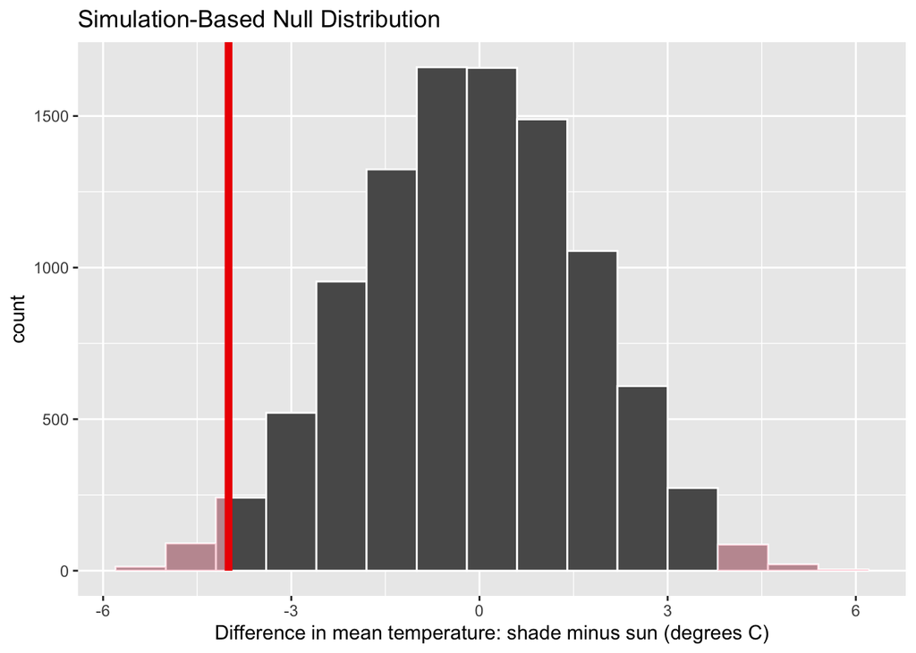

```r
# 10,000 shuffles approximate the randomization distribution.
# Design justification: the sharp null of no shade effect on any plot.
set.seed(student_seed + 12)
null_dist <- temperature |>
  specify(temp_c ~ treatment) |>
  hypothesize(null = "independence") |>
  generate(reps = 10000, type = "permute") |>
  calculate(stat = "diff in means", order = c("shade", "sun"))

visualize(null_dist) +
  shade_p_value(obs_stat = observed, direction = "both") +
  labs(x = "Difference in mean temperature: shade minus sun (degrees C)")
```

```r
null_dist |>
  get_p_value(obs_stat = observed, direction = "both")
```

```
# A tibble: 1 × 1
  p_value
    <dbl>
1   0.028
```

```r
# Manual two-tail counting, to match the classroom rule |D| >= 4.
# The exact null distribution here is symmetric. infer doubles a tail
# for its two-sided p-value, so finite-simulation answers can differ slightly.
tail_count <- sum(abs(null_dist$stat) >= abs(observed$stat) - 1e-10)
tibble(extreme = tail_count, simulations = nrow(null_dist),
       tail_fraction = tail_count / nrow(null_dist),
       corrected_mc_p = (tail_count + 1) / (nrow(null_dist) + 1))
```

```
# A tibble: 1 × 4
  extreme simulations tail_fraction corrected_mc_p
    <int>       <int>         <dbl>          <dbl>
1     251       10000        0.0251         0.0252
```

```r
# The +1 convention prevents reporting a zero Monte Carlo p-value.
```

## 3. A bootstrap confidence interval

A separate fictional simple random survey samples eight residents from a large city population. Treat observations as independent.

**In class:** run the data and `sample_mean` blocks, then only `one_bootstrap`. Inspect its eight values, note repeated or omitted values, and add its mean to a NEW whiteboard axis. Discuss the class pattern before running 10,000 resamples. The three-bootstrap block gives three additional means if requested.

```r
# 3. BOOTSTRAPPING: a separate small random survey from a large population
commute <- tibble(
  respondent = seq_len(8),
  minutes = c(10, 15, 15, 20, 25, 30, 35, 50)
)
sample_mean <- commute |>
  specify(response = minutes) |>
  calculate(stat = "mean")
sample_mean # 25 minutes
```

```
Response: minutes (numeric)
# A tibble: 1 × 1
   stat
  <dbl>
1    25
```

### One bootstrap resample first

Inspect the eight draws and contribute one mean to a separate board axis.

```r
# One bootstrap sample has eight rows. People can appear more than once.
set.seed(student_seed + 20)
one_bootstrap <- commute |>
  specify(response = minutes) |>
  generate(reps = 1, type = "bootstrap")
one_bootstrap # inspect the eight drawn values
```

```
Response: minutes (numeric)
# A tibble: 8 × 2
# Groups:   replicate [1]
  replicate minutes
      <int>   <dbl>
1         1      30
2         1      25
3         1      10
4         1      30
5         1      25
6         1      50
7         1      50
8         1      15
```

```r
one_bootstrap |>
  count(minutes, name = "appearances") # repeated values are allowed
```

```
# A tibble: 5 × 3
# Groups:   replicate [1]
  replicate minutes appearances
      <int>   <dbl>       <int>
1         1      10           1
2         1      15           1
3         1      25           2
4         1      30           2
5         1      50           2
```

```r
# Report THIS statistic as one dot on the whiteboard.
one_bootstrap |> calculate(stat = "mean")
```

```
Response: minutes (numeric)
# A tibble: 1 × 1
   stat
  <dbl>
1  29.4
```

**Pause:** describe the class bootstrap distribution.

### Three more resamples, if requested

```r
# Three more resamples: each row is a mean from eight draws.
set.seed(student_seed + 21)
my_three_bootstraps <- commute |>
  specify(response = minutes) |>
  generate(reps = 3, type = "bootstrap") |>
  calculate(stat = "mean")
my_three_bootstraps
```

```
Response: minutes (numeric)
# A tibble: 3 × 2
  replicate  stat
      <int> <dbl>
1         1  23.1
2         2  31.2
3         3  24.4
```

### Many bootstrap resamples

Run after the whiteboard discussion.

```r
set.seed(student_seed + 22)
boot_dist <- commute |>
  specify(response = minutes) |>
  generate(reps = 10000, type = "bootstrap") |>
  calculate(stat = "mean")

ci_95 <- boot_dist |>
  get_confidence_interval(level = 0.95, type = "percentile")
ci_95
```

```
# A tibble: 1 × 2
  lower_ci upper_ci
     <dbl>    <dbl>
1     16.9     33.8
```

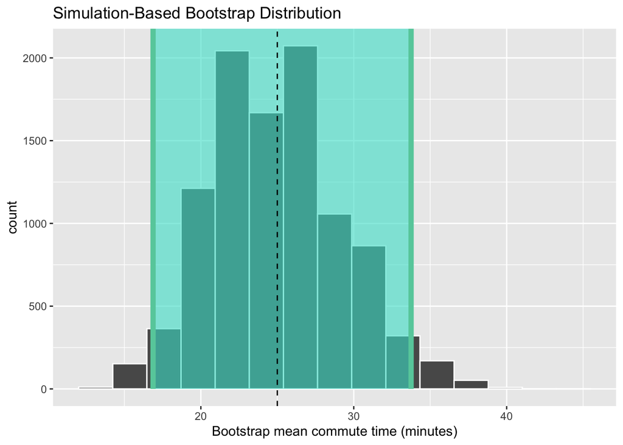

```r
visualize(boot_dist) +
  shade_confidence_interval(endpoints = ci_95) +
  geom_vline(xintercept = sample_mean$stat, linetype = "dashed") +
  labs(x = "Bootstrap mean commute time (minutes)")
```

```r
# An estimate of the standard error of the sample mean:
boot_dist |> summarise(bootstrap_se = sd(stat))
```

```
# A tibble: 1 × 1
  bootstrap_se
         <dbl>
1         4.30
```

```r
# Same data and resamples, a different confidence level:
ci_90 <- boot_dist |>
  get_confidence_interval(level = 0.90, type = "percentile")
ci_99 <- boot_dist |>
  get_confidence_interval(level = 0.99, type = "percentile")
bind_rows(`90%` = ci_90, `95%` = ci_95, `99%` = ci_99, .id = "level") |>
  mutate(width = upper_ci - lower_ci)
```

```
# A tibble: 3 × 4
  level lower_ci upper_ci width
  <chr>    <dbl>    <dbl> <dbl>
1 90%       18.1     32.5  14.4
2 95%       16.9     33.8  16.9
3 99%       15       36.9  21.9
```

```r
# Teaching caution: n = 8 is small and skewed. This percentile interval
# is approximate; bootstrapping does not guarantee nominal 95% coverage.
# It does not correct a biased sample or account for spatial dependence.
```

## 4. Optional investigations

The exact randomization check counts all equally likely allocations. The coverage function starts with a **new original sample each time**, rather than repeatedly resampling only the observed eight people. Run the commented calls explicitly if desired.

```r
# OPTIONAL: exact check of the shuffle (184,756 assignments).
# Run explicitly if desired. Distinct plot IDs matter even for equal values.
exact_randomization <- function() {
  choices <- combn(seq_len(nrow(temperature)), 10)
  first_sum <- colSums(matrix(temperature$temp_c[choices], nrow = 10))
  exact_stats <- (2 * first_sum - sum(temperature$temp_c)) / 10
  tibble(assignments = length(exact_stats),
         exact_p = mean(abs(exact_stats) >= abs(observed$stat) - 1e-10))
}
# exact_randomization()

# OPTIONAL: approximate bootstrap coverage across genuinely new samples.
# This function is defined, but not run automatically.
# Each repetition starts with a new sample from a known normal population.
bootstrap_coverage <- function(repetitions = 100, n = 30, reps = 500) {
  set.seed(535)
  intervals <- map_dfr(seq_len(repetitions), function(i) {
    new_sample <- tibble(minutes = rnorm(n, mean = 25, sd = 5))
    limits <- new_sample |>
      specify(response = minutes) |>
      generate(reps = reps, type = "bootstrap") |>
      calculate(stat = "mean") |>
      get_confidence_interval(level = 0.95, type = "percentile")
    mutate(limits, sample_number = i, covers = lower_ci <= 25 & upper_ci >= 25)
  })
  print(summarise(intervals, coverage_fraction = mean(covers)))
  ggplot(intervals, aes(y = sample_number, color = covers)) +
    geom_segment(aes(x = lower_ci, xend = upper_ci, yend = sample_number)) +
    geom_vline(xintercept = 25, linetype = "dashed") +
    labs(x = "Interval for the population mean", y = "New sample") +
    theme_minimal(base_size = 14)
}
# bootstrap_coverage()
```